# The Three-Step Approach: Automated and Manual

Labs created by Adam Garber and Dina Arch

Updated: November 05, 2024

`University of California, Santa Barbara`

1. Automated Three-Step
   - DU3STEP (Distal outcomes)
   - R3STEP (Latent class predictor)
2. Manual Three-step

**Data source:**

1. The first example utilizes a dataset on undergraduate *Cheating* available from the `poLCA` package (Dayton, 1998): [See documentation here](https://cran.r-project.org/web/packages/poLCA/poLCA.pdf)
2. The second examples utilizes the public-use dataset, *The Longitudinal Survey of American Youth* (**LSAY**): [See documentation here](https://www.lsay.org/)

Load packages

```r
library(MplusAutomation)
library(tidyverse) #collection of R packages designed for data science
library(here) #helps with filepaths
library(janitor) #clean_names
library(gt) # create tables
library(cowplot) # a ggplot theme
library(DiagrammeR) # create path diagrams
library(glue) # allows us to paste expressions into R code
library(data.table) # used for `melt()` function
library(poLCA)
here::i_am("three_step_mixtures.Rmd")
```

# Automated Three-Step

**Note**: Prior to adding covariates or distals enumeration must be conducted. See Lab 6 for examples of enumeration with MplusAutomation.

## Application: Undergraduate Cheating behavior

“Dichotomous self-report responses by 319 undergraduates to four questions about cheating behavior” (poLCA, 2016).

Prepare data

```r
data(cheating)

cheating <- cheating %>% clean_names()

df_cheat <-  cheating %>%
  dplyr::select(1:4) %>%
  mutate_all(funs(.-1)) %>%
  mutate(gpa = cheating$gpa)

# Detaching packages that mask the dpylr functions
detach(package:poLCA, unload = TRUE)
detach(package:MASS, unload = TRUE)
```

## DU3STEP

[interactive chart not shown]

**DU3STEP** incorporates distal outcome variables (assumed to have unequal means and variances) with mixture models.

### Run the **DU3step** model with `gpa` as distal outcome

```r
m_stepdu  <- mplusObject(
  TITLE = "DU3STEP - GPA as Distal",
  VARIABLE =
   "categorical = lieexam-copyexam;
    usevar = lieexam-copyexam;
    auxiliary = gpa (du3step);
    classes = c(2);",

  ANALYSIS =
   "estimator = mlr;
    type = mixture;
    starts = 500 100;
    processors = 10;",

  OUTPUT = "sampstat patterns tech11 tech14;",

  PLOT =
    "type = plot3;
     series = lieexam-copyexam(*);",

  usevariables = colnames(df_cheat),
  rdata = df_cheat)

m_stepdu_fit <- mplusModeler(m_stepdu,
                            dataout=here("auto_3step", "du3step.dat"),
                            modelout=here("auto_3step", "c2_du3step.inp") ,
                            check=TRUE, run = TRUE, hashfilename = FALSE)
```

### Plot Distal Outcome

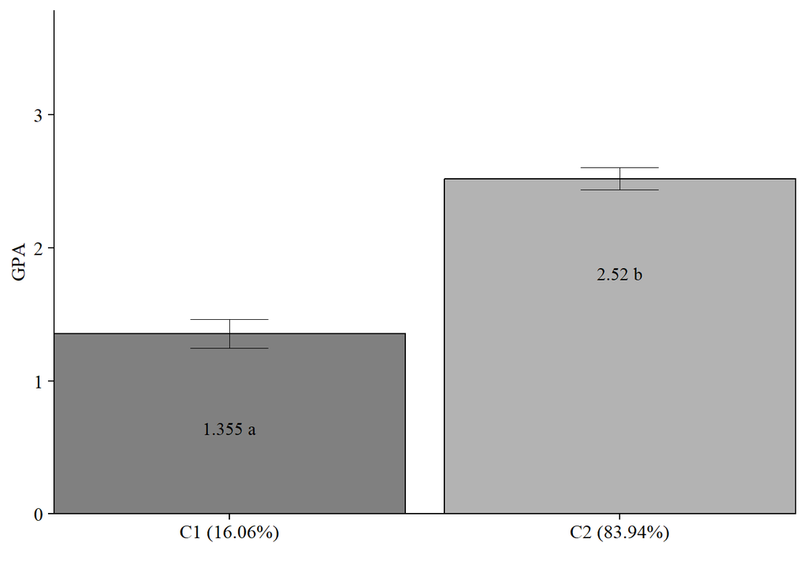

```r
modelParams <- readModels(here("auto_3step", "c2_du3step.out"))

# Extract class size
c_size <- as.data.frame(modelParams[["class_counts"]][["modelEstimated"]][["proportion"]]) %>%
  rename("cs" = 1) %>%
  mutate(cs = round(cs*100, 2))

c_size_val <- paste0("C", 1:nrow(c_size), glue(" ({c_size[1:nrow(c_size),]}%)"))


# Extract information as data frame
estimates <- as.data.frame(modelParams[["lcCondMeans"]][["overall"]]) %>%
  melt(id.vars = "var") %>%
  mutate(variable = as.character(variable),
         LatentClass = case_when(
           endsWith(variable, "1") ~ c_size_val[1],
           endsWith(variable, "2") ~ c_size_val[2])) %>% #Add to this based on the number of classes you have
  head(-3) %>%
  pivot_wider(names_from = variable, values_from = value) %>%
  unite("mean", contains("m"), na.rm = TRUE) %>%
  unite("se", contains("se"), na.rm = TRUE) %>%
  mutate(across(c(mean, se), as.numeric))

# Add labels (NOTE: You must change the labels to match the significance testing!!)
value_labels <- paste0(estimates$mean, c(" a"," b"))

# Plot bar graphs
estimates %>%
  ggplot(aes(fill = LatentClass, y = mean, x = LatentClass)) +
  geom_bar(position = "dodge", stat = "identity", color = "black") +
  geom_errorbar(aes(ymin=mean-se, ymax=mean+se),
                size=.3,
                width=.2,
                position=position_dodge(.9)) +
  geom_text(aes(y = mean, label = value_labels),
            family = "serif", size = 4,
            position=position_dodge(.9),
            vjust = 8) +
  scale_fill_grey(start = .5, end = .7) +
  labs(y="GPA", x="") +
  theme_cowplot() +
  theme(text = element_text(family = "serif", size = 12),
        axis.text.x = element_text(size=12),
        legend.position="none") +
  coord_cartesian(expand = FALSE,
                  ylim=c(0,max(estimates$mean*1.5))) # Change ylim based on distal outcome rang
```

```r
# Save plot
ggsave(here("figures","Du3STEP_plot.jpeg"),
       dpi=300, width=10, height = 7, units="in")
```

## R3STEP

[interactive chart not shown]

**R3STEP** incorporates latent class predictors with mixture models.

### Run the **R3STEP** model with `gpa` as the latent class predictor

```r
m_stepr  <- mplusObject(
  TITLE = "R3STEP - GPA as Predictor",
  VARIABLE =
   "categorical = lieexam-copyexam;
    usevar = lieexam-copyexam;
    auxiliary = gpa (R3STEP);
    classes = c(2);",

  ANALYSIS =
   "estimator = mlr;
    type = mixture;
    starts = 500 100;
    processors = 10;",

  OUTPUT = "sampstat patterns tech11 tech14;",

  PLOT =
    "type = plot3;
     series = lieexam-copyexam(*);",

  usevariables = colnames(df_cheat),
  rdata = df_cheat)

m_stepr_fit <- mplusModeler(m_stepr,
                            dataout=here("auto_3step", "r3step.dat"),
                            modelout=here("auto_3step", "c2_r3step.inp") ,
                            check=TRUE, run = TRUE, hashfilename = FALSE)
```

### Regression slopes and odds ratios

```r
TESTS OF CATEGORICAL LATENT VARIABLE MULTINOMIAL LOGISTIC REGRESSIONS USING
THE 3-STEP PROCEDURE

                                                    Two-Tailed
                    Estimate       S.E.  Est./S.E.    P-Value

 C#1      ON
    GPA               -0.698      0.255     -2.739      0.006

 Intercepts
    C#1               -0.241      0.460     -0.523      0.601

Parameterization using Reference Class 1

 C#2      ON
    GPA                0.698      0.255      2.739      0.006

 Intercepts
    C#2                0.241      0.460      0.523      0.601


ODDS RATIOS FOR TESTS OF CATEGORICAL LATENT VARIABLE MULTINOMIAL LOGISTIC REGRESSIONS
USING THE 3-STEP PROCEDURE

                                                95% C.I.
                    Estimate       S.E. Lower 2.5% Upper 2.5%

 C#1      ON
    GPA                0.498      0.127      0.302      0.820


Parameterization using Reference Class 1

 C#2      ON
    GPA                2.009      0.512      1.220      3.310
```

# Manual Three-step

[interactive chart not shown]

Integrate covariates and distals with a mixture model

**LCA Indicators & Auxiliary Variables: Math Attitudes Example**

| Name | Variable Description |
| --- | --- |
| enjoy | I enjoy math. |
| useful | Math is useful in everyday problems. |
| logical | Math helps a person think logically. |
| job | It is important to know math to get a good job. |
| adult | I will use math in many ways as an adult. |
| Auxiliary Variables |  |
| female | Self-reported student gender (0=Male, 1=Female). |
| math_irt | Standardized IRT math test score - 12th grade. |

The data can be found in the `data` folder and is called `lsay_subset.csv`.

```r
lsay_data <- read_csv(here("data","lsay_subset.csv")) %>%
  clean_names() %>%   # make variable names lowercase
  mutate(female = recode(gender, `1` = 0, `2` = 1)) # relabel values from 1,2 to 0,1
```

## ML Method

### Step 1 - Class Enumeration w/ Auxiliary Specification

This step is done after class enumeration (or after you have selected the best latent class model). In this example, the four class model was the best. Now, I am re-estimating the four-class model using `optseed` for efficiency. The difference here is the `SAVEDATA` command, where I can save the posterior probabilities and the modal class assignment for steps two and three.

```r
step1  <- mplusObject(
  TITLE = "Step 1 - Three-Step using LSAL",
  VARIABLE =
  "categorical = enjoy useful logical job adult;
   usevar = enjoy useful logical job adult;

   classes = c(4);

   auxiliary =   ! list all potential covariates and distals here
   female        ! covariate
   math_irt;      ! distal math test score in 12th grade ",

  ANALYSIS =
   "estimator = mlr;
    type = mixture;
    starts = 0;
    optseed = 568405;",

  SAVEDATA =
   "File=3step_savedata.dat;
    Save=cprob;",

  OUTPUT = "residual tech11 tech14",

  PLOT =
    "type = plot3;
    series = enjoy-adult(*);",

  usevariables = colnames(lsay_data),
  rdata = lsay_data)

step1_fit <- mplusModeler(step1,
                            dataout=here("manual_3step", "Step1.dat"),
                            modelout=here("manual_3step", "one.inp") ,
                            check=TRUE, run = TRUE, hashfilename = FALSE)
```

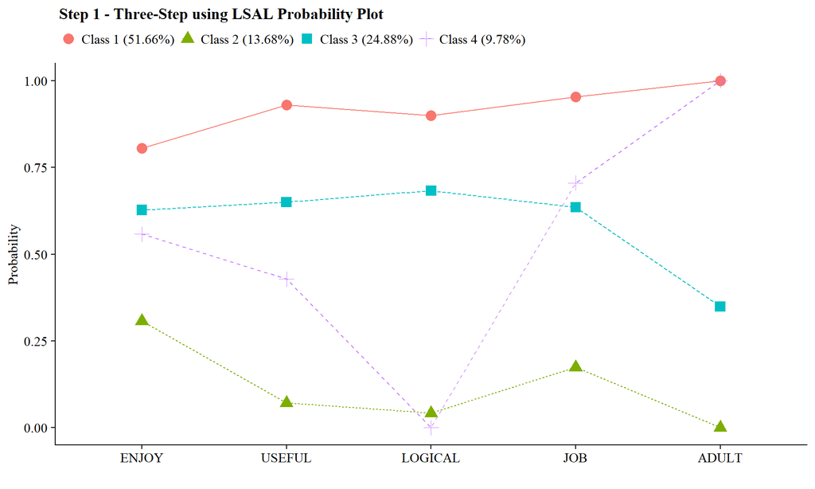

```r
source("plot_lca.txt")
output_lsay <- readModels(here("manual_3step","one.out"))

plot_lca(model_name = output_lsay)
```

### Step 2 - Determine Measurement Error

Extract logits for the classification probabilities for the most likely latent class

```r
logit_cprobs <- as.data.frame(output_lsay[["class_counts"]]
                                       [["logitProbs.mostLikely"]])
```

Extract saved dataset which is part of the mplusObject “step1_fit”

```r
savedata <- as.data.frame(output_lsay[["savedata"]])
```

Rename the column in savedata named “C” and change to “N”

```r
colnames(savedata)[colnames(savedata)=="C"] <- "N"
```

### Step 3 - Add Auxiliary Variables

Model with 1 covariate and 1 distal outcome

```r
step3  <- mplusObject(
  TITLE = "Step3 - 3step LSAY",

  VARIABLE =
 "nominal=N;
  usevar = n;

  classes = c(4);

  usevar = female math_irt;" ,

  ANALYSIS =
 "estimator = mlr;
  type = mixture;
  starts = 0;",

  DEFINE =
   "center female (grandmean);",

  MODEL =
  glue(
 " %OVERALL%

  math_irt on female; ! covariate as a predictor of the distal outcome
  C on female;        ! covariate as predictor of C

     %C#1%
  [n#1@{logit_cprobs[1,1]}]; ! MUST EDIT if you do not have a 4-class model.
  [n#2@{logit_cprobs[1,2]}];
  [n#3@{logit_cprobs[1,3]}];

  [math_irt](m1);    ! conditional distal mean
  math_irt;          ! conditional distal variance (freely estimated)

  %C#2%
  [n#1@{logit_cprobs[2,1]}];
  [n#2@{logit_cprobs[2,2]}];
  [n#3@{logit_cprobs[2,3]}];

  [math_irt](m2);
  math_irt;

  %C#3%
  [n#1@{logit_cprobs[3,1]}];
  [n#2@{logit_cprobs[3,2]}];
  [n#3@{logit_cprobs[3,3]}];

  [math_irt](m3);
  math_irt;

  %C#4%
  [n#1@{logit_cprobs[4,1]}];
  [n#2@{logit_cprobs[4,2]}];
  [n#3@{logit_cprobs[4,3]}];

  [math_irt](m4);
  math_irt; "),

  MODELCONSTRAINT =
   "New (diff12 diff13 diff23
    diff14 diff24 diff34);

    diff12 = m1-m2;  ! test pairwise distal mean differences
    diff13 = m1-m3;
    diff23 = m2-m3;
    diff14 = m1-m4;
    diff24 = m2-m4;
    diff34 = m3-m4;",

  MODELTEST = "     ! omnibus test of distal means
    m1=m2;
    m2=m3;
    m3=m4;",

  usevariables = colnames(savedata),
  rdata = savedata)

step3_fit <- mplusModeler(step3,
               dataout=here("manual_3step", "Step3.dat"),
               modelout=here("manual_3step", "three_starts.inp"),
               check=TRUE, run = TRUE, hashfilename = FALSE)
```

#### Wald Test Table

```r
modelParams <- readModels(here("manual_3step", "three.out"))

# Extract information as data frame
wald <- as.data.frame(modelParams[["summaries"]]) %>%
  dplyr::select(WaldChiSq_Value:WaldChiSq_PValue) %>%
  mutate(WaldChiSq_DF = paste0("(", WaldChiSq_DF, ")")) %>%
  unite(wald_test, WaldChiSq_Value, WaldChiSq_DF, sep = " ") %>%
  rename(pval = WaldChiSq_PValue) %>%
  mutate(pval = ifelse(pval<0.001, paste0("<.001*"),
                       ifelse(pval<0.05, paste0(scales::number(pval, accuracy = .001), "*"),
                              scales::number(pval, accuracy = .001))))

# Create table

wald_table <- wald %>%
  gt() %>%
    tab_header(
    title = "Wald Test of Paramter Constraints (Math)") %>%
    cols_label(
      wald_test = md("Wald Test (*df*)"),
      pval = md("*p*-value")) %>%
  cols_align(align = "center") %>%
  opt_align_table_header(align = "left") %>%
  gt::tab_options(table.font.names = "serif")

wald_table
```

Wald Test of Paramter Constraints (Math)

| Wald Test (*df*) | *p*-value |
| --- | --- |
| 69.134 (3) | <.001* |

Save figure

```r
gtsave(wald_table, here("figures","wald_table.docx"))
```

#### Table of Distal Outcome Differences

```r
# Extract information as data frame
diff <- as.data.frame(modelParams[["parameters"]][["unstandardized"]]) %>%
  filter(grepl("DIFF", param)) %>%
  dplyr::select(param:pval) %>%
  mutate(se = paste0("(", format(round(se,2), nsmall =2), ")")) %>%
  unite(estimate, est, se, sep = " ") %>%
  mutate(param = str_remove(param, "DIFF"),
         param = as.numeric(param)) %>%
  separate(param, into = paste0("Group", 1:2), sep = 1) %>%
  mutate(class = paste0("Class ", Group1, " vs ", Group2)) %>%
  select(class, estimate, pval) %>%
  mutate(pval = ifelse(pval<0.001, paste0("<.001*"),
                       ifelse(pval<0.05, paste0(scales::number(pval, accuracy = .001), "*"),
                              scales::number(pval, accuracy = .001))))

# Create table

diff %>%
  gt() %>%
    tab_header(
    title = "Distal Outcome Differences") %>%
    cols_label(
      class = "Class",
      estimate = md("Mean (*se*)"),
      pval = md("*p*-value")) %>%
    sub_missing(1:3,
              missing_text = "") %>%
  cols_align(align = "center") %>%
  opt_align_table_header(align = "left") %>%
  gt::tab_options(table.font.names = "serif")
```

Distal Outcome Differences

| Class | Mean (*se*) | *p*-value |
| --- | --- | --- |
| Class 1 vs 2 | 6.723 (0.98) | <.001* |
| Class 1 vs 3 | 3.108 (0.95) | 0.001* |
| Class 2 vs 3 | -3.615 (1.32) | 0.006* |
| Class 1 vs 4 | 7.034 (1.29) | <.001* |
| Class 2 vs 4 | 0.311 (1.45) | 0.830 |
| Class 3 vs 4 | 3.926 (1.49) | 0.008* |

#### Plot Distal Outcome

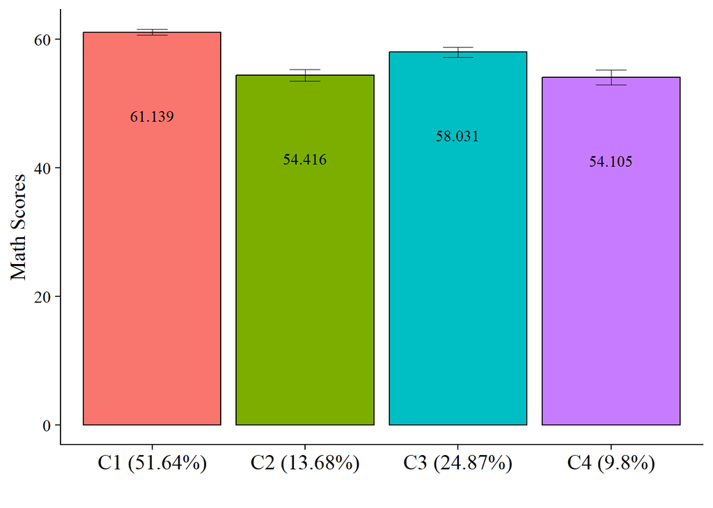

```r
# Extract class size
c_size <- as.data.frame(modelParams[["class_counts"]][["modelEstimated"]][["proportion"]]) %>%
  rename("cs" = 1) %>%
  mutate(cs = round(cs*100, 2))

c_size_val <- paste0("C", 1:nrow(c_size), glue(" ({c_size[1:nrow(c_size),]}%)"))


# Extract information as data frame
estimates <- as.data.frame(modelParams[["parameters"]][["unstandardized"]]) %>%
  filter(paramHeader == "Intercepts") %>%
  dplyr::select(param, est, se) %>%
  filter(param == "MATH_IRT") %>%
  mutate(across(c(est, se), as.numeric)) %>%
  mutate(LatentClass = c_size_val)

# Add labels (NOTE: You must change the labels to match the significance testing!!)
#value_labels <- paste0(estimates$est, c("a"," bc"," abd"," cd"))

estimates$LatentClass <- fct_inorder(estimates$LatentClass)

# Plot bar graphs
estimates %>%
  ggplot(aes(x=LatentClass, y = est, fill = LatentClass)) +
  geom_col(position = "dodge", stat = "identity", color = "black") +
  geom_errorbar(aes(ymin=est-se, ymax=est+se),
                size=.3,    # Thinner lines
                width=.2,
                position=position_dodge(.9)) +
  geom_text(aes(label = est),
            family = "serif", size = 4,
            position=position_dodge(.9),
            vjust = 8) +
 # scale_fill_grey(start = .4, end = .7) + # Remove for colorful bars
  labs(y="Math Scores", x="") +
  theme_cowplot() +
  theme(text = element_text(family = "serif", size = 15),
        axis.text.x = element_text(size=15),
        legend.position="none")
```

```r
# Save plot
ggsave(here("figures","ManualDistal_Plot.jpeg"),
       dpi=300, width=10, height = 7, units="in")
```

#### D on X

Is there a relation between the distal outcome (Math IRT Scores) and the covariate (Gender)?

```r
# Extract information as data frame
cov <- as.data.frame(modelParams[["parameters"]][["unstandardized"]]) %>%
  filter(param == "FEMALE") %>%
  mutate(param = str_replace(param, "FEMALE", "Gender"))%>%
  mutate(LatentClass = sub("^","Class ", LatentClass)) %>%
  dplyr::select(!paramHeader) %>%
  mutate(se = paste0("(", format(round(se,2), nsmall =2), ")")) %>%
    unite(estimate, est, se, sep = " ") %>%
  select(param, estimate, pval) %>%
  distinct(param, .keep_all=TRUE) %>%
  mutate(pval = ifelse(pval<0.001, paste0("<.001*"),
                       ifelse(pval<0.05, paste0(scales::number(pval, accuracy = .001), "*"),
                              scales::number(pval, accuracy = .001))))


# Create table

cov %>%
  gt(groupname_col = "LatentClass", rowname_col = "param") %>%
  tab_header(
    title = "Gender Predicting Math Scores") %>%
  cols_label(
    estimate = md("Estimate (*se*)"),
    pval = md("*p*-value")) %>%
  sub_missing(1:3,
              missing_text = "") %>%
  sub_values(values = c("999.000"), replacement = "-") %>%
  cols_align(align = "center") %>%
  opt_align_table_header(align = "left") %>%
  gt::tab_options(table.font.names = "serif")
```

Gender Predicting Math Scores

|  | Estimate (*se*) | *p*-value |
| --- | --- | --- |
| Gender | -1.108 (0.55) | 0.045* |

## BCH Method

### Step 1 - Class Enumeration w/ Auxiliary Specification and BCH Weights

```r
step1_bch  <- mplusObject(
  TITLE = "Step 1 - Three-Step - BCH Method",
  VARIABLE =
  "categorical = enjoy-adult;
   usevar = enjoy-adult;

   classes = c(4);

   auxiliary =   ! list all potential covariates and distals here
   female        ! covariate
   math_irt;      ! distal math test score in 12th grade ",

  ANALYSIS =
   "estimator = mlr;
    type = mixture;
    starts = 500 100;",

  SAVEDATA =
   "File=3step_savedata.dat;
    Save=bchweights; ! Here we save the BCH weights
    format = free;",

  OUTPUT = "sampstat residual tech11 tech14",

  PLOT =
    "type = plot3;
    series = enjoy-adult(*);",

  usevariables = colnames(lsay_data),
  rdata = lsay_data)

step1_fit_bch <- mplusModeler(step1_bch,
                            dataout=here("bch_mplus", "Step1.dat"),
                            modelout=here("bch_mplus", "Step1_bch.inp") ,
                            check=TRUE, run = TRUE, hashfilename = FALSE)
```

### Step 2 - Extract BCH Weights

Extract saved dataset which is part of the mplusObject “step1_fit_bch”

```r
savedata <- as.data.frame(step1_fit_bch[["results"]]
                                   [["savedata"]])
```

Rename the column in savedata named “C” and change to “N”

```r
colnames(savedata)[colnames(savedata)=="C"] <- "N"
```

### Step 3 - Add Auxiliary Variables and BCH Weights

```r
step3_bch  <- mplusObject(
  TITLE = "Step3 - 3step LSAY - BCH Method",

  VARIABLE =
 "nominal=N;
  usevar = n;
  classes = c(4);

  usevar = BCHW1-BCHW4 female math_irt;

  training = BCHW1-BCHW4(bch);" ,

  ANALYSIS =
 "estimator = mlr;
  type = mixture;
  starts = 0;",

  MODEL =
  glue(
 " %OVERALL%

   math_irt on female; ! covariate as a predictor of the distal outcome
  C on female;      ! covariate as predictor of C

  %C#1%

  [math_irt](m1);    ! conditional distal mean
  math_irt;          ! conditional distal variance (freely estimated)

  %C#2%

  [math_irt](m2);
  math_irt;

  %C#3%

  [math_irt](m3);
  math_irt;

  %C#4%

  [math_irt](m4);
  math_irt; "),

  MODELCONSTRAINT =
   "New (diff12 diff13 diff23
    diff14 diff24 diff34);

    diff12 = m1-m2;  ! test pairwise distal mean differences
    diff13 = m1-m3;
    diff23 = m2-m3;
    diff14 = m1-m4;
    diff24 = m2-m4;
    diff34 = m3-m4;",

  MODELTEST = "     ! omnibus test of distal means
    m1=m2;
    m2=m3;
    m3=m4;",

  usevariables = colnames(savedata),
  rdata = savedata)

step3_fit_bch <- mplusModeler(step3_bch,
               dataout=here("bch_mplus", "Step3.dat"),
               modelout=here("bch_mplus", "Step3_bch.inp"),
               check=TRUE, run = TRUE, hashfilename = FALSE)
```

# Latent class variable as moderator

Read in data from Step 1 of ML Method

```r
# Read in model with SAVEDATA information
output_lsay <- readModels(here("manual_3step","one.out"))

#Extract logits for the classification probabilities for the most likely latent class
logit_cprobs <- as.data.frame(output_lsay[["class_counts"]]
                                       [["logitProbs.mostLikely"]])
# Read in savedata
savedata <- as.data.frame(output_lsay[["savedata"]])

#Rename the column in savedata named "C" and change to "N"
colnames(savedata)[colnames(savedata)=="C"] <- "N"
```

Step 3: LCA Moderation

```r
step3mod  <- mplusObject(
  TITLE = "LCA Moderation",

  VARIABLE =
 "nominal=N;
  usevar = n;

  classes = c(4);

  usevar = female math_irt;" ,

  ANALYSIS =
 "estimator = mlr;
  type = mixture;
  starts = 0;",

  MODEL =
  glue(
 "!DISTAL = math_irt, COVARIATE = female, MODERATOR = C

  %OVERALL%
  math_irt on female;
  math_irt;

     %C#1%
  [n#1@{logit_cprobs[1,1]}];
  [n#2@{logit_cprobs[1,2]}];
  [n#3@{logit_cprobs[1,3]}];

  math_irt on female(s1);  ! conditional slope (class 1)
  [math_irt](m1);          ! conditional distal mean
  math_irt;                ! conditional distal variance (freely estimated)

  %C#2%
  [n#1@{logit_cprobs[2,1]}];
  [n#2@{logit_cprobs[2,2]}];
  [n#3@{logit_cprobs[2,3]}];

  math_irt on female(s2);
  [math_irt](m2);
  math_irt;

  %C#3%
  [n#1@{logit_cprobs[3,1]}];
  [n#2@{logit_cprobs[3,2]}];
  [n#3@{logit_cprobs[3,3]}];

  math_irt on female(s3);
  [math_irt](m3);
  math_irt;

  %C#4%
  [n#1@{logit_cprobs[4,1]}];
  [n#2@{logit_cprobs[4,2]}];
  [n#3@{logit_cprobs[4,3]}];

  math_irt on female(s4);
  [math_irt](m4);
  math_irt; "),

  MODELCONSTRAINT =
   "New (
   diff12 diff13 diff23
   diff14 diff24 diff34
   slope12 slope13 slope23
    slope14 slope24 slope34);

    diff12 = m1-m2;  ! test distal outcome differences
    diff13 = m1-m3;
    diff23 = m2-m3;
    diff14 = m1-m4;
    diff24 = m2-m4;
    diff34 = m3-m4;

    slope12 = s1-s2;  ! test pairwise slope differences
    slope13 = s1-s3;
    slope23 = s2-s3;
    slope14 = s1-s4;
    slope24 = s2-s4;
    slope34 = s3-s4;",

  MODELTEST = " ! can run only a single Omnibus test per model
    s1=s2;
    s2=s3;
    s3=s4;",

  usevariables = colnames(savedata),
  rdata = savedata)

step3mod_fit <- mplusModeler(step3mod,
               dataout=here("lca_mod", "mod.dat"),
               modelout=here("lca_mod", "Step3_mod_LSAY.inp"),
               check=TRUE, run = TRUE, hashfilename = FALSE)
```

### Table of Distal Outcome Differences

```r
modelParams <- readModels(here("lca_mod", "Step3_mod_LSAY.out"))

# Extract information as data frame
diff <- as.data.frame(modelParams[["parameters"]][["unstandardized"]]) %>%
  filter(grepl("DIFF", param)) %>%
  dplyr::select(param:pval) %>%
  mutate(se = paste0("(", format(round(se,2), nsmall =2), ")")) %>%
  unite(estimate, est, se, sep = " ") %>%
  mutate(param = str_remove(param, "DIFF"),
         param = as.numeric(param)) %>%
  separate(param, into = paste0("Group", 1:2), sep = 1) %>%
  mutate(class = paste0("Class ", Group1, " vs ", Group2)) %>%
  select(class, estimate, pval)


# Create table

diff %>%
  gt() %>%
    tab_header(
    title = "Distal Outcome Differences") %>%
    cols_label(
      class = "Class",
      estimate = md("Mean (*se*)"),
      pval = md("*p*-value")) %>%
    sub_missing(1:3,
              missing_text = "") %>%
  fmt(3,
    fns = function(x)
      ifelse(x<0.05, paste0(scales::number(x, accuracy = .001), "*"),
             scales::number(x, accuracy = .001))
  ) %>%
  cols_align(align = "center") %>%
  opt_align_table_header(align = "left") %>%
  gt::tab_options(table.font.names = "serif")
```

Distal Outcome Differences

| Class | Mean (*se*) | *p*-value |
| --- | --- | --- |
| Class 1 vs 2 | 3.996 (1.23) | 0.001* |
| Class 1 vs 3 | 1.46 (1.00) | 0.143 |
| Class 2 vs 3 | -2.536 (1.45) | 0.081 |
| Class 1 vs 4 | 4.758 (1.43) | 0.001* |
| Class 2 vs 4 | 0.762 (1.70) | 0.654 |
| Class 3 vs 4 | 3.298 (1.57) | 0.035* |

### Plot Distal Outcome

This is the intercept plotted across class. Here, the intercept is the expected value of math IRT scores when the predictor, `female`, is zero (and in this case 0 equals male)

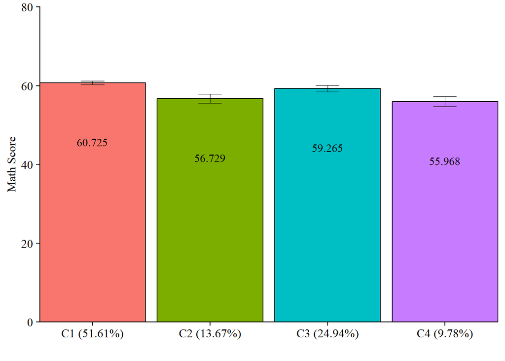

```r
# Extract class size
c_size <- as.data.frame(modelParams[["class_counts"]][["modelEstimated"]][["proportion"]]) %>%
  rename("cs" = 1) %>%
  mutate(cs = round(cs*100, 2))

c_size_val <- paste0("C", 1:nrow(c_size), glue(" ({c_size[1:nrow(c_size),]}%)"))


# Extract information as data frame
estimates <- as.data.frame(modelParams[["parameters"]][["unstandardized"]]) %>%
  filter(paramHeader == "Intercepts") %>%
  dplyr::select(param, est, se) %>%
  filter(param == "MATH_IRT") %>%
  mutate(across(c(est, se), as.numeric)) %>%
  mutate(LatentClass = c_size_val)

# Plot bar graphs
estimates %>%
  ggplot(aes(x=LatentClass, y = est, fill = LatentClass)) +
  geom_col(position = "dodge", stat = "identity", color = "black") +
  geom_errorbar(aes(ymin=est-se, ymax=est+se),
                size=.3,    # Thinner lines
                width=.2,
                position=position_dodge(.9)) +
  geom_text(aes(label = est),
            family = "serif", size = 4,
            position=position_dodge(.9),
            vjust = 8) +
  #scale_fill_grey(start = .4, end = .7) +
  labs(y="Math Score", x="") +
  theme_cowplot() +
  theme(text = element_text(family = "serif", size = 12),
        axis.text.x = element_text(size=12),
        legend.position="none") +
  coord_cartesian(ylim=c(0,80),  # Change ylim based on distal outcome range
                  expand = FALSE)
```

```r
# Save plot
ggsave(here("figures","Moderation_Distal.jpeg"),
       dpi=300, width=10, height = 7, units="in")
```

### Plot Interaction

#### Bar plot

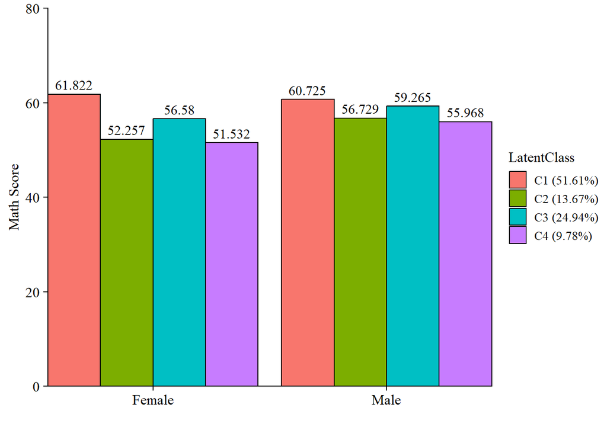

```r
# Extract information as data frame
desc <- as.data.frame(modelParams$sampstat$univariate.sample.statistics) %>%
  rownames_to_column("Variables")

# Select min amd max values of covariate
xmin <- desc %>%
  filter(Variables == "FEMALE") %>%
  dplyr::select(Minimum) %>%
  as.numeric()
xmax <- desc %>%
  filter(Variables == "FEMALE") %>%
  dplyr::select(Maximum) %>%
  as.numeric()

# Add slope and intercept, Min and Max values
line <- as.data.frame(modelParams$parameters$unstandardized) %>%
  filter(str_detect(paramHeader, 'ON|Inter')) %>%
  unite("param", paramHeader:param, remove = TRUE) %>%
  mutate(param = replace(param,agrep(".ON",param),"slope"),
         param = replace(param,agrep("Inter", param), "intercept"),
         LatentClass = factor(LatentClass, labels = c_size_val)) %>%
  dplyr::select(param, est, LatentClass) %>%
  pivot_wider(names_from = param, values_from = est) %>%
  add_column(x_max = xmax,
         x_min = xmin)


# Add column with y values
data <- line %>%
  mutate(y_min = (slope*xmin) + intercept,
         y_max = (slope*xmax) + intercept) %>%
  dplyr::select(-slope, -intercept) %>%
  pivot_longer(-LatentClass,
               names_to = c("xvalues", "yvalues"),
               names_sep="_" ) %>%
  pivot_wider(names_from = xvalues, values_from = value) %>%
  dplyr::select(-yvalues) %>%
  mutate(x = case_when(
           x == 1 ~ "Female",
           x == 0 ~ "Male"))

# Plot bar graphs
data %>%
  ggplot(aes(x=factor(x), y = y, fill = LatentClass)) +
  geom_col(position = "dodge", stat = "identity", color = "black") +
  geom_text(aes(label = y),
            family = "serif", size = 4,
            position=position_dodge(.9),
            vjust = -.5) +
  #scale_fill_grey(start = .4, end = .7) +
  labs(y="Math Score", x="") +
  theme_cowplot() +
  theme(text = element_text(family = "serif", size = 12),
        axis.text.x = element_text(size=12)) +
  coord_cartesian(ylim=c(0,80),  # Change ylim based on distal outcome range
                  expand = FALSE)
```

```r
# Save plot
ggsave(here("figures","Moderation_Interaction.jpeg"),
       dpi=300, width=10, height = 7, units="in")
```

#### Line plot

Here we can visualize the slopes.

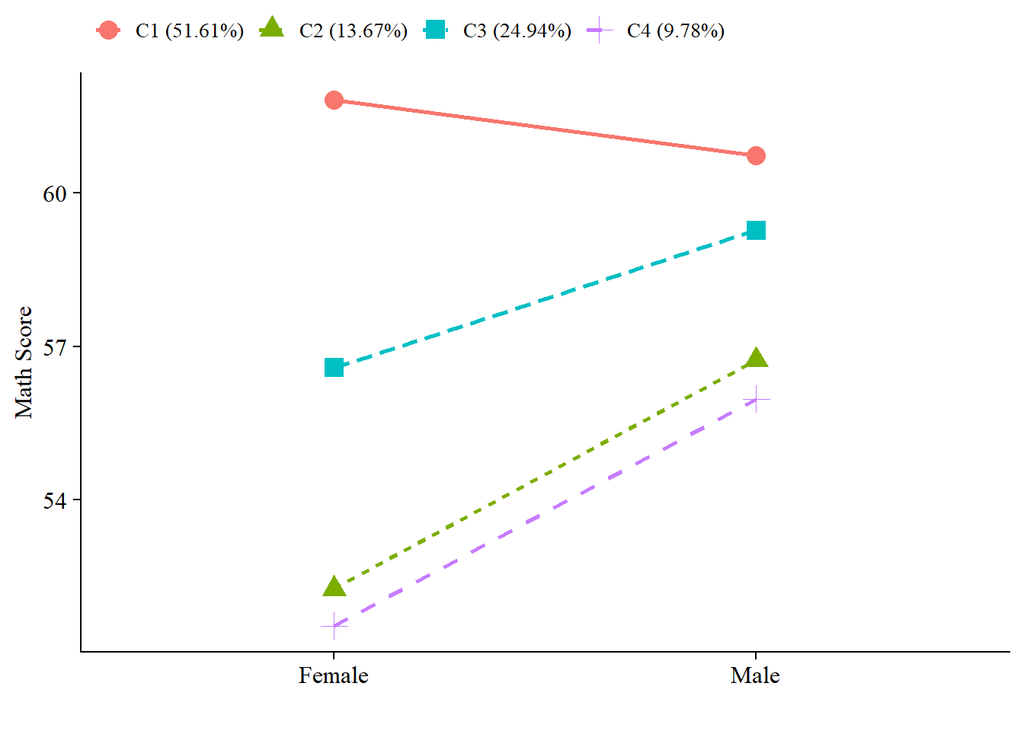

```r
# Minimum and Maximum Values
desc <- as.data.frame(modelParams$sampstat$univariate.sample.statistics) %>%
  rownames_to_column("Variables")

# Select min amd max values of covariate
xmin <- desc %>%
  filter(Variables == "FEMALE") %>%
  dplyr::select(Minimum) %>%
  as.numeric()
xmax <- desc %>%
  filter(Variables == "FEMALE") %>%
  dplyr::select(Maximum) %>%
  as.numeric()

# Add slope and intercept, Min and Max values
line <- as.data.frame(modelParams$parameters$unstandardized) %>%
  filter(str_detect(paramHeader, 'ON|Inter')) %>%
  unite("param", paramHeader:param, remove = TRUE) %>%
  mutate(param = replace(param,agrep(".ON",param),"slope"),
         param = replace(param,agrep("Inter", param), "intercept"),
         LatentClass = factor(LatentClass, labels = c_size_val)) %>%
  dplyr::select(param, est, LatentClass) %>%
  pivot_wider(names_from = param, values_from = est) %>%
  add_column(x_max = xmax,
         x_min = xmin)


# Add column with y values
data <- line %>%
  mutate(y_min = (slope*xmin) + intercept,
         y_max = (slope*xmax) + intercept) %>%
  dplyr::select(-slope, -intercept) %>%
  pivot_longer(-LatentClass,
               names_to = c("xvalues", "yvalues"),
               names_sep="_" ) %>%
  pivot_wider(names_from = xvalues, values_from = value) %>%
  dplyr::select(-yvalues) %>%
  mutate(x = case_when(
           x == 1 ~ "Female",
           x == 0 ~ "Male"))

# Plot
data %>%
  ggplot(aes(
    x = factor(x),
    y = y,
    color = LatentClass,
    group = LatentClass,
    lty = LatentClass,
    shape = LatentClass
  )) +
  geom_point(size = 4) +
  geom_line(aes(group = LatentClass), size = 1) +
  labs(x = "",
       y = "Math Score") +
  #scale_colour_grey(start = .3, end = .6) +
  theme_cowplot() +
  theme(
    text = element_text(family = "serif", size = 12),
    axis.text.x = element_text(size = 12),
    legend.text = element_text(family = "serif", size = 10),
    legend.position = "top",
    legend.title = element_blank()
  )
```

```r
# Save
ggsave(here("figures","Moderation_Slope.jpeg"),             #
       dpi=500, width=10, height = 7, units="in")
```

It’s also important to report the slope coefficients. Which ones would you assume are significant based on the plots?

# References

Drew A. Linzer, Jeffrey B. Lewis (2011). poLCA: An R Package for Polytomous Variable Latent Class Analysis. Journal of Statistical Software, 42(10), 1-29. URL http://www.jstatsoft.org/v42/i10/.

Hallquist, M. N., & Wiley, J. F. (2018). MplusAutomation: An R Package for Facilitating Large-Scale Latent Variable Analyses in Mplus. Structural equation modeling: a multidisciplinary journal, 25(4), 621-638.

Miller, J. D., Hoffer, T., Suchner, R., Brown, K., & Nelson, C. (1992). LSAY codebook. Northern Illinois University.

Muthén, B. O., Muthén, L. K., & Asparouhov, T. (2017). Regression and mediation analysis using Mplus. Los Angeles, CA: Muthén & Muthén.

Muthén, L.K. and Muthén, B.O. (1998-2017). Mplus User’s Guide. Eighth Edition. Los Angeles, CA: Muthén & Muthén

R Core Team (2017). R: A language and environment for statistical computing. R Foundation for Statistical Computing, Vienna, Austria. URL http://www.R-project.org/

Wickham et al., (2019). Welcome to the tidyverse. Journal of Open Source Software, 4(43), 1686, https://doi.org/10.21105/joss.01686

[figure not shown]